#Name: Sweta Kumari #ANALYSIS OF VARIANCE

#1. One-way Analysis of Variance: #Read the oneway file.

```r
oneway<-read.table("C:\\Users\\Sweta\\Documents\\Data\\oneway.txt",header=T)
attach(oneway)
names(oneway)
```

```
## [1] "Growth"      "Photoperiod"
```

#Calculate mean of growth using tapply function:

```r
tapply(Growth,Photoperiod,mean)
```

```
##       Long      Short  Very.long Very.short
##   2.500000   2.166667   3.166667   1.666667
```

#To change the order of the output in Very.short,Short,Long,Very.long

```r
Photoperiod<-ordered(Photoperiod,levels=c("Very.short","Short","Long","Very.long"))
```

#Caluclate mean for new ordered output:

```r
tapply(Growth,Photoperiod,mean)
```

```
## Very.short      Short       Long  Very.long
##   1.666667   2.166667   2.500000   3.166667
```

#To find Photoperiod is factor variable

```r
is.factor(Photoperiod)
```

```
## [1] TRUE
```

#Use aov directive to show the anova table for the “oneway.txt” dataset.Capture the result in one.way object.

```r
one.way<-aov(Growth~Photoperiod)
```

#Use summary function to see the result of anova table

```r
summary(one.way)
```

```
##             Df Sum Sq Mean Sq F value Pr(>F)
## Photoperiod  3   7.12   2.375   1.462  0.255
## Residuals   20  32.50   1.625
```

#2. Two way analysis of variance #Remove Growth and Photoperiod variables and detach the oneway.txt dataset

```r
rm("Growth", "Photoperiod")
detach(oneway)
```

#Read the twoway file.

```r
twoway<-read.table("C:\\Users\\Sweta\\Documents\\Data\\twoway.txt",header=T)
attach(twoway)
names(twoway)
```

```
## [1] "Growth"      "Photoperiod" "Genotype"
```

#Find the mean growth rate for 6 genotypes

```r
tapply(Growth,Genotype,mean)
```

```
##    A    B    C    D    E    F
## 3.00 4.50 1.50 1.50 2.00 1.75
```

#Use aov directive to show the anova table for the “twoway.txt” dataset.Capture the result in two.way object.

```r
two.way<-aov(Growth~Genotype+Photoperiod)
```

#Use summary function to see the result of anova table

```r
summary(two.way)
```

```
##             Df Sum Sq Mean Sq F value   Pr(>F)
## Genotype     5 27.875   5.575  18.081 7.09e-06 ***
## Photoperiod  3  7.125   2.375   7.703   0.0024 **
## Residuals   15  4.625   0.308
## ---
## Signif. codes:  0 '***' 0.001 '**' 0.01 '*' 0.05 '.' 0.1 ' ' 1
```

#3. Two-way Factorial Analysis of Variance #Read the factorial file.

```r
factorial<-read.table("C:\\Users\\Sweta\\Documents\\Data\\factorial.txt",header=T)
factorial
```

```
##    growth diet  coat
## 1     6.6    A light
## 2     7.2    A light
## 3     6.9    B light
## 4     8.3    B light
## 5     7.9    C light
## 6     9.2    C light
## 7     8.3    A  dark
## 8     8.7    A  dark
## 9     8.1    B  dark
## 10    8.5    B  dark
## 11    9.1    C  dark
## 12    9.0    C  dark
```

```r
attach(factorial)
```

#Use aov directive to show the anova table for the “factorial.txt” dataset.Capture the result in model object.

```r
model<-aov(growth~diet*coat)
```

#Use summary function to see the result of anova table

```r
summary(model)
```

```
##             Df Sum Sq Mean Sq F value Pr(>F)
## diet         2 2.6600  1.3300   3.677 0.0907 .
## coat         1 2.6133  2.6133   7.226 0.0361 *
## diet:coat    2 0.6867  0.3433   0.949 0.4383
## Residuals    6 2.1700  0.3617
## ---
## Signif. codes:  0 '***' 0.001 '**' 0.01 '*' 0.05 '.' 0.1 ' ' 1
```

#Find sum of growth for all 6 combinations

```r
tapply(growth,list(coat,diet),sum)
```

```
##          A    B    C
## dark  17.0 16.6 18.1
## light 13.8 15.2 17.1
```

#Sum of squares of subtotal

```r
SSAB<-sum(as.vector(tapply(growth,list(coat,diet),sum))^2)/2
```

#Correction factor

```r
CF<-sum(growth)^2/length(growth)
```

#Fins sum of squares (SSAB–SSA-SSB-CF)

```r
SSAB-CF-2.66-2.61333
```

```
## [1] 0.68667
```

#Update model and remove interaction term

```r
model2<-update(model ,  ~ .  -  diet:coat)
```

#Use anova directive to compare both models.

```r
anova(model,model2)
```

```
## Analysis of Variance Table
##
## Model 1: growth ~ diet * coat
## Model 2: growth ~ diet + coat
##   Res.Df    RSS Df Sum of Sq      F Pr(>F)
## 1      6 2.1700
## 2      8 2.8567 -2  -0.68667 0.9493 0.4383
```

#Summary of variance table for model2

```r
summary(model2)
```

```
##             Df Sum Sq Mean Sq F value Pr(>F)
## diet         2  2.660  1.3300   3.725 0.0719 .
## coat         1  2.613  2.6133   7.319 0.0269 *
## Residuals    8  2.857  0.3571
## ---
## Signif. codes:  0 '***' 0.001 '**' 0.01 '*' 0.05 '.' 0.1 ' ' 1
```

#Remove diet variable as p value is not significant.

```r
model3<-update(model2, ~. -diet)
```

#Compare model3 and model2

```r
anova(model2,model3)
```

```
## Analysis of Variance Table
##
## Model 1: growth ~ diet + coat
## Model 2: growth ~ coat
##   Res.Df    RSS Df Sum of Sq      F Pr(>F)
## 1      8 2.8567
## 2     10 5.5167 -2     -2.66 3.7246 0.0719 .
## ---
## Signif. codes:  0 '***' 0.001 '**' 0.01 '*' 0.05 '.' 0.1 ' ' 1
```

#Summary of model3

```r
summary(model3)
```

```
##             Df Sum Sq Mean Sq F value Pr(>F)
## coat         1  2.613  2.6133   4.737 0.0546 .
## Residuals   10  5.517  0.5517
## ---
## Signif. codes:  0 '***' 0.001 '**' 0.01 '*' 0.05 '.' 0.1 ' ' 1
```

#To find mean for all three diet

```r
tapply(growth,diet,mean)
```

```
##    A    B    C
## 7.70 7.95 8.80
```

#New factor for diet: 1 for A, B and 2 for C

```r
diet2<-factor(1+(diet=="C"))
diet2
```

```
##  [1] 1 1 1 1 2 2 1 1 1 1 2 2
## Levels: 1 2
```

#Update model3 and add diet2

```r
model4<-update(model3, ~. +diet2)
```

#Compare model3 and model4

```r
anova(model3,model4)
```

```
## Analysis of Variance Table
##
## Model 1: growth ~ coat
## Model 2: growth ~ coat + diet2
##   Res.Df    RSS Df Sum of Sq      F  Pr(>F)
## 1     10 5.5167
## 2      9 2.9817  1     2.535 7.6518 0.02189 *
## ---
## Signif. codes:  0 '***' 0.001 '**' 0.01 '*' 0.05 '.' 0.1 ' ' 1
```

#To check for interaction between diet2 and coat

```r
model5<-update(model4, ~. +diet2:coat)
```

#Compare model 4 and model5

```r
anova(model4,model5)
```

```
## Analysis of Variance Table
##
## Model 1: growth ~ coat + diet2
## Model 2: growth ~ coat + diet2 + coat:diet2
##   Res.Df    RSS Df Sum of Sq      F Pr(>F)
## 1      9 2.9817
## 2      8 2.7000  1   0.28167 0.8346 0.3877
```

#model5 is inadequate so model4 is minimal adequate model

```r
summary(model4)
```

```
##             Df Sum Sq Mean Sq F value Pr(>F)
## coat         1  2.613  2.6133   7.888 0.0204 *
## diet2        1  2.535  2.5350   7.652 0.0219 *
## Residuals    9  2.982  0.3313
## ---
## Signif. codes:  0 '***' 0.001 '**' 0.01 '*' 0.05 '.' 0.1 ' ' 1
```

#3. Three-way Factorial Analysis of Variance #Read the file

```r
Daphnia.data<-read.table("C:\\Users\\Sweta\\Documents\\Data\\Daphnia.txt",header=T)
attach(Daphnia.data)
names(Daphnia.data)
```

```
## [1] "Growth.rate" "Water"       "Detergent"   "Daphnia"
```

```r
factorial<-aov(Growth.rate~Water*Detergent*Daphnia)
```

#Summary function for anova table

```r
summary(factorial)
```

```
##                         Df Sum Sq Mean Sq F value   Pr(>F)
## Water                    1   1.99   1.985   2.850 0.097838 .
## Detergent                3   2.21   0.737   1.059 0.375478
## Daphnia                  2  39.18  19.589  28.128 8.23e-09 ***
## Water:Detergent          3   0.17   0.058   0.084 0.968608
## Water:Daphnia            2  13.73   6.866   9.859 0.000259 ***
## Detergent:Daphnia        6  20.60   3.433   4.930 0.000532 ***
## Water:Detergent:Daphnia  6   5.85   0.975   1.399 0.234324
## Residuals               48  33.43   0.696
## ---
## Signif. codes:  0 '***' 0.001 '**' 0.01 '*' 0.05 '.' 0.1 ' ' 1
```

#Create a 2dimensional table of mean growth rates

```r
tapply(Growth.rate,list(Detergent,Daphnia),mean)
```

```
##          Clone1   Clone2   Clone3
## BrandA 2.732227 3.919002 5.003268
## BrandB 2.929140 4.402931 4.698062
## BrandC 3.071335 4.772805 4.019397
## BrandD 2.626797 5.213745 2.834151
```

#To show the interaction effects

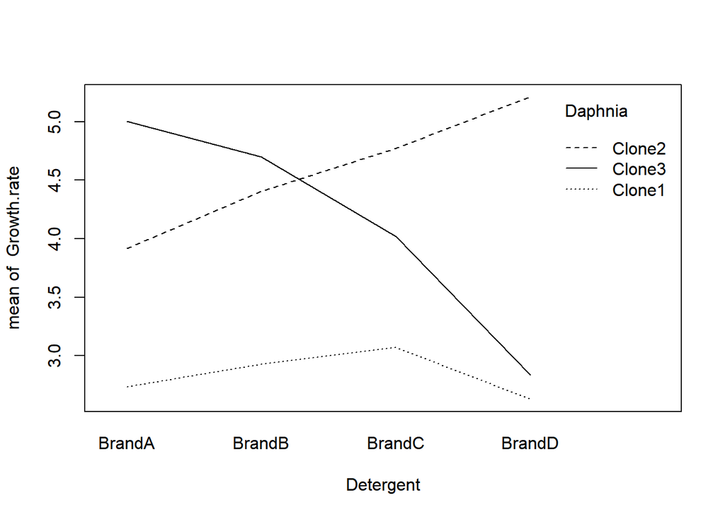

```r
interaction.plot(Detergent,Daphnia,Growth.rate)
```